# Intel vs AMD: salud financiera 2022–2025

- Mostrar todo el código
- Ocultar todo el código
- Ver el código fuente

Liquidez, solvencia, rentabilidad, flujo de caja y Altman Z (SEC EDGAR, 10-K)

Autor/a

Benedict Bagoyo

Fecha de publicación

30 de septiembre de 2026

**ImportanteAlcance**

Análisis de **salud financiera** a partir de los estados contables (10-K). **No es una recomendación de inversión** ni valora si las acciones están caras o baratas. Importes en USD (B$ = miles de millones). Periodo principal FY2022–2025; FY2019–2021 solo como contexto (AMD antes de Xilinx no es comparable).

# Resumen ejecutivo

- **AMD es claramente más sólida en todos los bloques en 2025:** ratio corriente 2,85 frente a 2,02; deuda/patrimonio 0,05 frente a 0,41; AMD tiene **caja neta** de 7,3 B$ e Intel **deuda neta** de 9,2 B$; margen operativo 10,7 % frente a -4,2 %; margen de FCF 19,4 % frente a -9,4 %.
- **Altman Z’’ 2025 (métrica principal): AMD 6,85, Intel 3,24.** Las dos en «zona segura» (> 2,6), pero Intel estuvo en **zona gris en 2024 (2,01)** y su Z’’ se sostiene casi solo con partidas de balance heredadas (beneficios retenidos y patrimonio): la rentabilidad actual (X3) aporta -0,07.
- **Con el Z’ (secundario), Intel está en «peligro» desde 2023** (1,15 en 2025; umbral 1,23). AMD está en «gris» (2,74). El Z’ pesa más el EBIT y la rotación, justo los puntos débiles de Intel.
- **La mejora de Intel en 2025 viene de la financiación, no de la operación.** El Z’’ sube 1,23, y de eso 0,96 procede de X1 (circulante) y X4 (patrimonio), impulsados por más acciones (4.330 → 4.994 M), minoritarios (5,8 B$ → 12,1 B$) y aportaciones de socios. El EBIT sigue negativo (-2,2 B$), el FCF también (-4,9 B$) y la cobertura de intereses es -2,0×.
- **El Z’’ de AMD está inflado por el fondo de comercio de Xilinx.** Fondo de comercio + intangibles = **66 %** de su patrimonio en 2025 (88 % en 2022). Con patrimonio **tangible**, su Z’’ baja a **3,69** en 2025 (segura) y a **1,49 (gris)** en 2022.
- **Visión crediticia:** Intel es el emisor más arriesgado: más deuda, EBIT negativo, FCF negativo cuatro años seguidos (-44 B$ acumulados) y dependencia de financiación externa para su capex. AMD no muestra riesgo de solvencia; su riesgo es operativo (días de inventario 80 → 142) y de ciclo de producto.

# 1 Datos y validación de la extracción frente al Día 1

**Fuente:** API oficial de SEC EDGAR (companyfacts XBRL), 10-K anuales. El Día 2 re-extrae todas las partidas **seleccionando por fecha de cierre y duración del periodo**, no por el campo `fy`.

**Código**

```r
d1 <- res("diferencias_vs_dia1.csv")
d1 |> count(estado, name = "n") |> transmute(Estado = estado, `Nº de valores` = n) |> tabla(align = "lr")
```

Tabla 1: Comparación de los valores del Día 1 (financials_clean.csv) con la re-extracción del Día 2.

| Estado | Nº de valores |
| --- | --- |
| FALTABA en Día 1 — ahora extraído | 10 |
| igual | 70 |

- **Las cifras del Día 1 eran correctas:** de 70 valores comparados, **70 coinciden y 0 son distintos**. El spot-check de ingresos 2022–2024 cuadra al redondeo (tabla siguiente).
- **Faltaban 10 valores:** el **pasivo total** (ninguna empresa usa el tag `Liabilities`; se deriva como `LiabilitiesAndStockholdersEquity − patrimonio total (incl. minoritarios) − patrimonio temporal`) y los **gastos por intereses de Intel 2024–2025** (Intel pasó de `InterestExpense` a `InterestExpenseNonoperating`; en el solape 2022–2023 los valores son idénticos, lo que valida el empalme).
- **Selección del ejercicio no robusta en el Día 1:** `fy` es el año del 10-K que presenta el dato, no el del periodo; `drop_duplicates(keep="last")` acertó por el orden interno del JSON. El Día 2 elimina ese riesgo.
- **Otras diferencias de tags documentadas:** efectivo de Intel 2019–2023 incluye efectivo restringido; inversiones a c/p con tags distintos (por eso el ratio de caja se da con y sin inversiones); deuda corriente de AMD con dos tags del mismo importe (se toma uno); acciones del balance (us-gaap), no de portada (dei).

**Código**

```r
res("spotcheck_ingresos.csv") |>
  transmute(Empresa = ticker, Año = fiscal_year, Esperado = fnum(esperado_bn, 2), Extraído = fnum(extraido_bn, 3), OK = ifelse(ok, "✓", "✗")) |>
  tabla(align = "lrrrc")
```

Tabla 2: Spot-check de ingresos (B$).

| Empresa | Año | Esperado | Extraído | OK |
| --- | --- | --- | --- | --- |
| AMD | 2022 | 23,60 | 23,601 | ✓ |
| AMD | 2023 | 22,70 | 22,680 | ✓ |
| AMD | 2024 | 25,80 | 25,785 | ✓ |
| INTC | 2022 | 63,10 | 63,054 | ✓ |
| INTC | 2023 | 54,20 | 54,228 | ✓ |
| INTC | 2024 | 53,10 | 53,101 | ✓ |

### 1.0.1 Control del pasivo total derivado

**Código**

```r
pt <- res("pasivo_total_derivacion.csv")
pt |> arrange(ticker, fiscal_year) |>
  transmute(Empresa = ticker, Año = fiscal_year, `Pasivo derivado (B$)` = fnum(total_liabilities / 1e9, 2),
            `Suma de componentes (B$)` = fnum(tl_suma_componentes / 1e9, 2),
            `Residuo (M$)` = fnum(residuo_vs_componentes / 1e6, 0), Control = control) |>
  tabla(align = "lrrrrl")
```

Tabla 3: Pasivo total derivado frente a la suma de partidas de pasivo con tags propios (control no circular).

| Empresa | Año | Pasivo derivado (B$) | Suma de componentes (B$) | Residuo (M$) | Control |
| --- | --- | --- | --- | --- | --- |
| AMD | 2019 | 3,20 | 3,20 | 0 | cuadra |
| AMD | 2020 | 3,12 | 3,12 | 0 | cuadra |
| AMD | 2021 | 4,92 | 4,92 | 0 | cuadra |
| AMD | 2022 | 12,83 | 12,83 | 0 | cuadra |
| AMD | 2023 | 11,99 | 11,99 | 0 | cuadra |
| AMD | 2024 | 11,66 | 11,66 | 0 | cuadra |
| AMD | 2025 | 13,93 | 13,93 | 0 | cuadra |
| INTC | 2019 | 58,87 | 50,53 | 8.331 | residuo = partidas presentadas por separado (ver notes) |
| INTC | 2020 | 72,05 | 62,27 | 9.788 | residuo = partidas presentadas por separado (ver notes) |
| INTC | 2021 | 73,02 | 66,04 | 6.972 | residuo = partidas presentadas por separado (ver notes) |
| INTC | 2022 | 78,82 | 78,82 | 0 | cuadra |
| INTC | 2023 | 81,61 | 81,61 | 0 | cuadra |
| INTC | 2024 | 91,45 | 91,45 | 0 | cuadra |
| INTC | 2025 | 85,07 | 85,07 | 0 | cuadra |

**NotaControl actualizado**

La interpretación original advertía de que el control «Assets − patrimonio = 0 $» era **tautológico**. El análisis lo sustituyó por un control **no circular**: se compara el pasivo derivado con la suma de partidas de pasivo con tags propios (pasivo corriente + deuda l/p + otros pasivos no corrientes; en AMD, además arrendamientos e impuestos diferidos). **Cuadra al millón en 11 de 14 empresa-años, todos los de 2022–2025.** Los residuos de Intel 2019–2021 (contexto) se explican por partidas que entonces se presentaban por separado (impuestos a pagar l/p, impuestos diferidos y pasivos contractuales l/p).

### 1.0.2 Calendario

Los dos cierran el último sábado de diciembre. **FY2022 tuvo 53 semanas en ambas empresas** (cierre 31-dic-2022): los flujos de 2022 están inflados ~2 % frente al resto de años. No altera ninguna conclusión.

# 2 Liquidez

**Código**

```r
tabla_ratios(c(current_ratio = "Corriente", quick_ratio = "Prueba ácida", cash_ratio = "Caja (solo efectivo)",
               cash_ratio_incl_st_inv = "Caja + inv. c/p"),
             list(current_ratio = fx2, quick_ratio = fx2, cash_ratio = fx2, cash_ratio_incl_st_inv = fx2))
liq <- function(tk, yr) Fi(tk, yr, "cash") + Fi(tk, yr, "short_term_investments")
```

Tabla 4: Ratios de liquidez (veces).

| Ratio | Intel (INTC) 2022 | Intel (INTC) 2023 | Intel (INTC) 2024 | Intel (INTC) 2025 | AMD 2022 | AMD 2023 | AMD 2024 | AMD 2025 |
| --- | --- | --- | --- | --- | --- | --- | --- | --- |
| Corriente | 1,57 | 1,54 | 1,33 | 2,02 | 2,36 | 2,51 | 2,62 | 2,85 |
| Prueba ácida | 1,16 | 1,15 | 0,98 | 1,65 | 1,77 | 1,86 | 1,83 | 2,01 |
| Caja (solo efectivo) | 0,35 | 0,25 | 0,23 | 0,45 | 0,76 | 0,59 | 0,52 | 0,59 |
| Caja + inv. c/p | 0,88 | 0,89 | 0,62 | 1,18 | 0,92 | 0,86 | 0,70 | 1,12 |

- **AMD:** liquidez holgada que **mejora de forma monótona** (el ratio corriente sube en 3 de 3 años). En 2025 el activo corriente pasa de 19,0 B$ a 26,9 B$, financiado con su propio flujo de caja (FCF 6,7 B$).
- **Intel:** se **deteriora hasta 2024** (prueba ácida < 1) y **salta en 2025**: efectivo + inversiones a c/p pasan de 22,1 B$ a 37,4 B$ en un año con FCF de -4,9 B$. **Esa caja no la generó la operación**, vino de la financiación (ver «Flujo de caja»).
- **Lectura:** en 2025 los dos tienen liquidez suficiente. Incluyendo inversiones, Intel incluso supera a AMD (1,18 frente a 1,12). Pero la de AMD es **autogenerada y recurrente**, y la de Intel **captada y no recurrente**.

**Código**

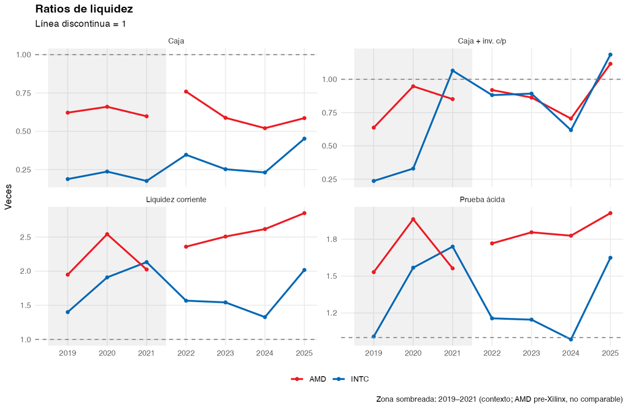

Figura 1: Liquidez de Intel y AMD. La liquidez de AMD mejora cada año con caja propia; el salto de Intel en 2025 procede de la financiación.

```r
include_graphics("figures/fig02_liquidez.png")
```

# 3 Solvencia y endeudamiento

**Código**

```r
tabla_ratios(c(debt_to_equity = "Deuda financiera / patrimonio", liabilities_to_assets = "Pasivo total / activo",
               net_debt = "Deuda neta (B$)", interest_coverage = "Cobertura de intereses (EBIT / gasto por intereses)",
               cobertura_ebit_sobre_intereses_pagados = "EBIT / intereses pagados en caja"),
             list(debt_to_equity = fx2, liabilities_to_assets = fx2, net_debt = fbn, interest_coverage = fxx,
                  cobertura_ebit_sobre_intereses_pagados = fxx))
```

Tabla 5: Solvencia y endeudamiento.

| Ratio | Intel (INTC) 2022 | Intel (INTC) 2023 | Intel (INTC) 2024 | Intel (INTC) 2025 | AMD 2022 | AMD 2023 | AMD 2024 | AMD 2025 |
| --- | --- | --- | --- | --- | --- | --- | --- | --- |
| Deuda financiera / patrimonio | 0,41 | 0,47 | 0,50 | 0,41 | 0,05 | 0,04 | 0,03 | 0,05 |
| Pasivo total / activo | 0,43 | 0,43 | 0,47 | 0,40 | 0,19 | 0,18 | 0,17 | 0,18 |
| Deuda neta (B$) | 13,7 | 24,2 | 27,9 | 9,2 | -3,4 | -3,3 | -3,4 | -7,3 |
| Cobertura de intereses (EBIT / gasto por intereses) | 4,7× | 0,1× | -11,3× | -2,0× | 14,4× | 3,8× | 20,7× | 28,2× |
| EBIT / intereses pagados en caja | 5,1× | 0,2× | -11,8× | -2,0× | 14,9× | 4,8× | 26,4× | 40,6× |

- **AMD:** prácticamente sin deuda (3,2 B$ de deuda frente a 10,6 B$ de caja e inversiones). Su cobertura de 28× es anecdótica (intereses de solo 0,13 B$). La caída de 2023 se debe a un EBIT deprimido por la amortización de intangibles de Xilinx, **no a más deuda**.
- **Intel:** la deuda bruta sube de 42,1 B$ (2022) a 50,0 B$ (2024) y baja a 46,6 B$ en 2025. La deuda neta cae con fuerza en 2025, **pero por el lado de la caja**, no por amortizar deuda. Lo más relevante: **el EBIT no cubre los intereses desde 2023**. Los intereses pagados en caja pasan de 0,46 B$ a 1,11 B$.
- **Matiz:** los gastos por intereses de Intel son **netos de intereses capitalizados** (se activan en las fábricas en construcción): la cobertura contable **sobreestima** la capacidad de pago. La columna «EBIT / intereses pagados en caja» usa los intereses efectivamente pagados como contraste (no es una cobertura «en caja», que usaría flujo operativo o EBITDA).
- **Lectura:** el endeudamiento contable de Intel (pasivo/activo 0,40) es moderado para una industrial intensiva en capital. El problema **no es el nivel de deuda sino la falta de beneficio operativo y de caja para servirla**.

**Código**

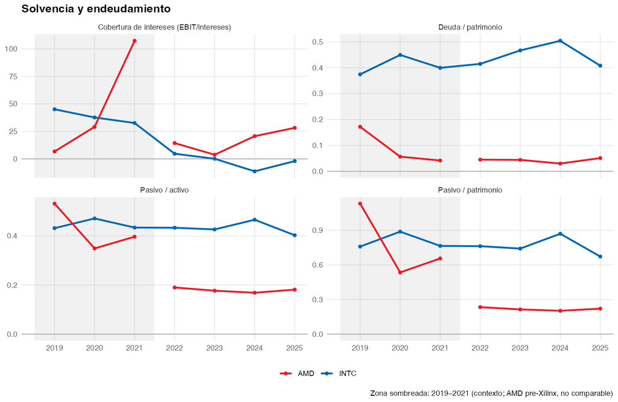

Figura 2: Solvencia: AMD apenas tiene deuda; el EBIT de Intel no cubre los intereses desde 2023.

```r
include_graphics("figures/fig03_solvencia.png")
```

# 4 Rentabilidad y eficiencia

**Código**

```r
tabla_ratios(c(revenue_growth_yoy = "Crecimiento interanual", gross_margin = "Margen bruto", operating_margin = "Margen operativo",
               net_margin = "Margen neto", roe = "ROE (patrimonio final)", asset_turnover = "Rotación de activos",
               rd_intensity = "I+D / ingresos", inventory_days = "Días de inventario (medio)"),
             list(revenue_growth_yoy = fpc, gross_margin = fpc, operating_margin = fpc, net_margin = fpc, roe = fpc,
                  asset_turnover = fx2, rd_intensity = fpc, inventory_days = fd))
cagr <- function(tk) cg$cagr_2022_2025[cg$ticker == tk]
```

Tabla 6: Rentabilidad, crecimiento y eficiencia.

| Ratio | Intel (INTC) 2022 | Intel (INTC) 2023 | Intel (INTC) 2024 | Intel (INTC) 2025 | AMD 2022 | AMD 2023 | AMD 2024 | AMD 2025 |
| --- | --- | --- | --- | --- | --- | --- | --- | --- |
| Crecimiento interanual | -20,2 % | -14,0 % | -2,1 % | -0,5 % | 43,6 % | -3,9 % | 13,7 % | 34,3 % |
| Margen bruto | 42,6 % | 40,0 % | 32,7 % | 34,8 % | 44,9 % | 46,1 % | 49,4 % | 49,5 % |
| Margen operativo | 3,7 % | 0,2 % | -22,0 % | -4,2 % | 5,4 % | 1,8 % | 7,4 % | 10,7 % |
| Margen neto | 12,7 % | 3,1 % | -35,3 % | -0,5 % | 5,6 % | 3,8 % | 6,4 % | 12,5 % |
| ROE (patrimonio final) | 7,9 % | 1,6 % | -18,9 % | -0,2 % | 2,4 % | 1,5 % | 2,9 % | 6,9 % |
| Rotación de activos | 0,35 | 0,28 | 0,27 | 0,25 | 0,35 | 0,33 | 0,37 | 0,45 |
| I+D / ingresos | 27,8 % | 29,6 % | 31,2 % | 26,1 % | 21,2 % | 25,9 % | 25,0 % | 23,4 % |
| Días de inventario (medio) | 121 | 137 | 119 | 126 | 80 | 121 | 141 | 142 |

* El crecimiento de AMD en 2022 es **inorgánico** (Xilinx se consolida desde 2022); los días de inventario de AMD 2022 mezclan balances antes y después de la adquisición (con inventario final: 106 → 165 días).

**Código**

```r
iv <- fi |> select(ticker, fiscal_year, revenue, periodo) |> mutate(ticker = factor(ticker, c("INTC", "AMD")))
plot_ly(iv, x = ~fiscal_year, y = ~revenue / 1e9, color = ~ticker, colors = pal, type = "bar",
        opacity = ~ifelse(periodo == "contexto", 0.45, 1),
        hovertemplate = "%{fullData.name} %{x}: %{y:.1f} B$<extra></extra>") |>
  layout(barmode = "group", xaxis = list(title = "", dtick = 1), yaxis = list(title = "Ingresos (B$)"),
         legend = list(orientation = "h", y = 1.08),
         shapes = list(list(type = "rect", x0 = 2018.5, x1 = 2021.5, yref = "paper", y0 = 0, y1 = 1,
                            fillcolor = "rgba(150,150,150,0.08)", line = list(width = 0))),
         annotations = list(list(x = 2020, y = 1.02, yref = "paper", text = "contexto (no comparable)",
                                 showarrow = FALSE, font = list(size = 11, color = "#666")))) |>
  pl_cfg()
```

[interactive chart not shown]

Figura 3: Ingresos anuales (B$). Las barras claras (2019–2021) son contexto.

- **Crecimiento:** CAGR de ingresos 2022–2025 **+13,6 % en AMD** y **-5,7 % en Intel**. En 2025 AMD factura el **66 %** de lo que factura Intel (37 % en 2022). La «mejora» del crecimiento de Intel solo significa que **deja de caer**.
- **Márgenes:** el margen bruto de AMD sube de forma monótona y el de Intel cae 7,8 pp. En 2024 Intel registra un EBIT de -11,7 B$ y un resultado neto de -18,8 B$; la diferencia apunta a un cargo no operativo o fiscal grande, **a verificar en el 10-K de 2024**. Ese año incluye 7,0 B$ de reestructuración y deterioros.
- **ROE de AMD bajo pese a la buena marcha** (6,9 % en 2025): el patrimonio está inflado por el fondo de comercio de Xilinx y el EBIT soporta 2,3–2,8 B$/año de amortización de intangibles (sin salida de caja). Su rentabilidad económica es **mejor que la contable**, como confirma el FCF.
- **Eficiencia:** la rotación de AMD sube (0,35 → 0,45); la de Intel **baja en 3 de 3 años** (0,35 → 0,25) porque su base de activos crece con fábricas en construcción mientras los ingresos caen.
- **Señal de alerta en AMD:** días de inventario 80 → 142 (inventario 3,8 B$ → 7,9 B$). Puede ser acumulación deliberada o riesgo de obsolescencia; los datos no permiten distinguirlo.

**Código**

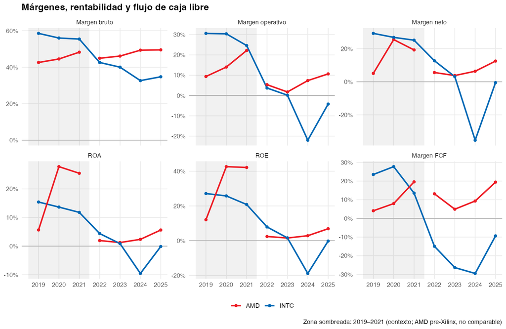

Figura 4: Márgenes, rentabilidad y FCF.

```r
include_graphics("figures/fig04_margenes_rentabilidad.png")
```

# 5 Flujo de caja

**Código**

```r
fc <- fi |> filter(fiscal_year %in% anios) |>
  left_join(ra |> select(ticker, fiscal_year, capex_intensity, fcf_margin), by = c("ticker", "fiscal_year")) |>
  transmute(ticker, fiscal_year, `Flujo operativo` = fnum(operating_cash_flow / 1e9, 1), Capex = fnum(capex / 1e9, 1),
            FCF = fnum(free_cash_flow / 1e9, 1), `Margen FCF` = fpct(fcf_margin), `Capex / ingresos` = fpct(capex_intensity),
            `Aportaciones de minoritarios` = ifelse(is.na(proceeds_minority), "—", fnum(proceeds_minority / 1e9, 1))) |>
  pivot_longer(-c(ticker, fiscal_year), names_to = "Concepto", values_to = "v") |>
  mutate(col = paste(ticker, fiscal_year)) |> select(-ticker, -fiscal_year) |>
  pivot_wider(names_from = col, values_from = v)
fc |> select(Concepto, all_of(paste("INTC", anios)), all_of(paste("AMD", anios))) |>
  kbl(format = "html", align = c("l", rep("r", 8)), col.names = c("Concepto", anios, anios)) |>
  kable_styling(bootstrap_options = c("striped", "hover", "condensed"), full_width = FALSE) |>
  add_header_above(c(" " = 1, "Intel (INTC)" = 4, "AMD" = 4)) |> row_spec(3, bold = TRUE)
pm_intc <- sum(sapply(anios, \(y) coalesce(Fi("INTC", y, "proceeds_minority"), 0)))
```

Tabla 7: Flujo de caja (B$) e intensidad de capex.

| Concepto | Intel (INTC) 2022 | Intel (INTC) 2023 | Intel (INTC) 2024 | Intel (INTC) 2025 | AMD 2022 | AMD 2023 | AMD 2024 | AMD 2025 |
| --- | --- | --- | --- | --- | --- | --- | --- | --- |
| Flujo operativo | 15,4 | 11,5 | 8,3 | 9,7 | 3,6 | 1,7 | 3,0 | 7,7 |
| Capex | 24,8 | 25,8 | 23,9 | 14,6 | 0,5 | 0,5 | 0,6 | 1,0 |
| FCF | -9,4 | -14,3 | -15,7 | -4,9 | 3,1 | 1,1 | 2,4 | 6,7 |
| Margen FCF | -14,9 % | -26,3 % | -29,5 % | -9,4 % | 13,2 % | 4,9 % | 9,3 % | 19,4 % |
| Capex / ingresos | 39,4 % | 47,5 % | 45,1 % | 27,7 % | 1,9 % | 2,4 % | 2,5 % | 2,8 % |
| Aportaciones de minoritarios | 0,9 | 1,5 | 12,7 | 5,1 | — | — | — | — |

- **Modelos de negocio opuestos:** AMD es *fabless* (capex < 3 % de las ventas) y convierte ~el 20 % de las ventas en caja libre en 2025. Intel es un fabricante integrado en plena expansión: capex del 28 %–47 % de las ventas.
- **Intel ha quemado 44 B$ de FCF en cuatro años** (AMD ha generado 13,4 B$). Lo ha cubierto con deuda, con aportaciones de socios minoritarios en proyectos de fábricas (20,2 B$ en 2022–2025 según `ProceedsFromMinorityShareholders`; socios identificados en la prensa como Brookfield/Apollo *(fuente externa — verificar)*) y, en 2025, con ampliaciones de capital (a verificar en el 10-K 2025).
- **La mejora del FCF de Intel en 2025** (-15,7 B$ → -4,9 B$) se debe sobre todo al **recorte del capex** (-9,3 B$); el flujo operativo mejora solo 1,4 B$. Recortar capex es una palanca de supervivencia, no una mejora operativa.
- **FCF GAAP frente a ajustado:** Intel presenta un FCF no-GAAP que resta las aportaciones de socios al capex. Aquí se usa el FCF GAAP (flujo operativo − capex bruto), que **mide la caja que genera la empresa por sí sola**.

**Código**

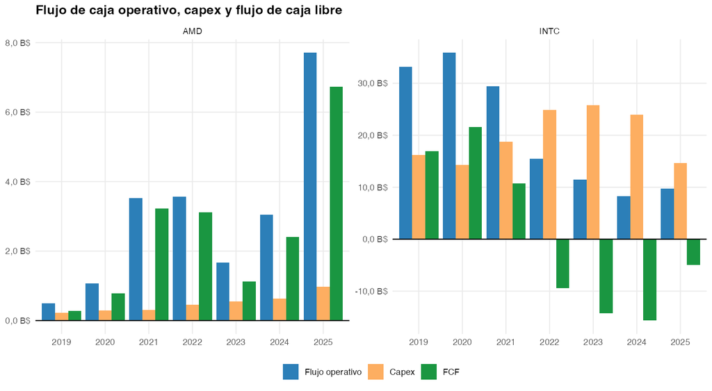

Figura 5: Flujo operativo, capex y FCF.

```r
include_graphics("figures/fig09_flujo_caja.png")
```

## 5.1 Resumen de tendencias 2022–2025

**Código**

```r
tr <- res("tendencia_ratios_2022_2025.csv")
det_col <- if ("valoracion_detalle" %in% names(tr)) "valoracion_detalle" else "valoracion"
tr |>
  mutate(v = paste0(.data[[det_col]], ifelse(monotona, " (monótona)", ""))) |>
  select(ratio, etiqueta, ticker, v) |>
  pivot_wider(names_from = ticker, values_from = v) |>
  transmute(Ratio = etiqueta, Intel = INTC, AMD) |>
  tabla(align = "lll")
```

Tabla 8: Dirección de cada ratio entre 2022 y 2025 (descriptivo; n = 4 años, sin inferencia).

| Ratio | Intel | AMD |
| --- | --- | --- |
| Ratio de liquidez corriente | mejora | mejora (monótona) |
| Prueba ácida | mejora | mejora |
| Ratio de caja | mejora | empeora |
| Ratio de caja (incl. inversiones c/p) | mejora | mejora |
| Deuda financiera / patrimonio | mejora | empeora |
| Pasivo total / patrimonio | mejora | mejora |
| Pasivo total / activo | mejora | mejora |
| Cobertura de intereses (EBIT/intereses) | empeora (pasa a negativo) | mejora |
| Margen bruto | empeora | mejora (monótona) |
| Margen operativo | empeora (pasa a negativo) | mejora |
| Margen neto | empeora (pasa a negativo) | mejora |
| ROA (sobre activo final) | empeora (pasa a negativo) | mejora |
| ROE (sobre patrimonio final) | empeora (pasa a negativo) | mejora |
| Rotación de activos | empeora (monótona) | mejora |
| Crecimiento de ingresos interanual | menos negativo (los ingresos siguen cayendo) (monótona) | crece menos (sigue creciendo) |
| Intensidad de I+D | empeora | mejora |
| Margen de flujo de caja libre | menos negativo (sigue en negativo) | mejora |
| Días de inventario | empeora | empeora (monótona) |
| Altman Z'' | empeora | mejora (monótona) |
| Altman Z' | empeora | mejora (monótona) |

# 6 Altman Z-Score

## 6.1 Modelos

- **Z’’ (Altman 1995, primario):** 6,56·X1 + 3,26·X2 + 6,72·X3 + 1,05·X4; zonas < 1,1 peligro / 1,1–2,6 gris / > 2,6 segura. Usa patrimonio **contable** y **no incluye la rotación (X5)**, por lo que es adecuado para comparar un modelo *fabless* (AMD) con uno intensivo en activos (Intel).
- **Z’ (1983, secundario):** 0,717·X1 + 0,847·X2 + 3,107·X3 + 0,420·X4 + 0,998·X5; zonas < 1,23 / 1,23–2,9 / > 2,9. Pensado para manufactureras privadas; da más peso al EBIT y a la rotación.
- **X1** = capital circulante/activo; **X2** = beneficios retenidos/activo; **X3** = EBIT/activo; **X4** = patrimonio contable (incl. minoritarios)/pasivo; **X5** = ventas/activo.

## 6.2 Resultados

**Código**

```r
az |> filter(fiscal_year %in% anios) |>
  transmute(ticker, fiscal_year, `Z''` = paste0(fnum(z_pp), " (", zona_z_pp, ")"), `Z'` = paste0(fnum(z_p), " (", zona_z_p, ")")) |>
  pivot_longer(c(`Z''`, `Z'`), names_to = "Modelo", values_to = "v") |>
  pivot_wider(names_from = fiscal_year, values_from = v) |>
  arrange(desc(Modelo), ticker) |>
  transmute(Serie = paste(Modelo, ticker), `2022`, `2023`, `2024`, `2025`) |>
  tabla(align = "lrrrr")
```

Tabla 9: Altman Z’’ y Z’ con su zona.

| Serie | 2022 | 2023 | 2024 | 2025 |
| --- | --- | --- | --- | --- |
| Z'' AMD | 5,44 (segura) | 5,94 (segura) | 6,60 (segura) | 6,85 (segura) |
| Z'' INTC | 3,38 (segura) | 3,12 (segura) | 2,01 (gris) | 3,24 (segura) |
| Z' AMD | 2,29 (gris) | 2,42 (gris) | 2,68 (gris) | 2,74 (gris) |
| Z' INTC | 1,34 (gris) | 1,21 (peligro) | 0,82 (peligro) | 1,15 (peligro) |

**Código**

```r
zband <- function(lo, hi, col) list(type = "rect", xref = "paper", x0 = 0, x1 = 1, y0 = lo, y1 = hi,
                                     fillcolor = col, line = list(width = 0), layer = "below")
zplot <- function(col, bands, ytitle, ymax) {
  d <- az |> mutate(seg = ifelse(fiscal_year <= 2021, "ctx", "main"))
  p <- plot_ly()
  for (tk in c("INTC", "AMD")) for (sg in c("ctx", "main")) {
    dd <- filter(d, ticker == tk, seg == sg)
    p <- add_trace(p, data = dd, x = ~fiscal_year, y = dd[[col]], type = "scatter", mode = "lines+markers",
                   name = tk, legendgroup = tk, showlegend = sg == "main",
                   line = list(color = pal[[tk]], width = 3, dash = ifelse(sg == "ctx", "dot", "solid")),
                   marker = list(color = pal[[tk]], size = 8),
                   hovertemplate = paste0(tk, " %{x}: %{y:.2f}<extra></extra>"))
  }
  p |> layout(shapes = bands, xaxis = list(title = "", dtick = 1), yaxis = list(title = ytitle, range = c(min(0, min(az[[col]]) - 0.2), ymax)),
              legend = list(orientation = "h", y = 1.08)) |> pl_cfg()
}
zplot("z_pp", list(zband(-5, 1.1, "rgba(213,94,0,0.12)"), zband(1.1, 2.6, "rgba(150,150,150,0.15)"), zband(2.6, 12, "rgba(0,158,115,0.10)")),
      "Z''", 8) |>
  layout(annotations = list(
    list(x = 1, xref = "paper", xanchor = "right", y = 0.5, text = "peligro < 1,1", showarrow = FALSE, font = list(size = 10, color = "#8a3b00")),
    list(x = 1, xref = "paper", xanchor = "right", y = 1.85, text = "gris 1,1–2,6", showarrow = FALSE, font = list(size = 10, color = "#555")),
    list(x = 1, xref = "paper", xanchor = "right", y = 7.6, text = "segura > 2,6", showarrow = FALSE, font = list(size = 10, color = "#006b4e"))))
```

[interactive chart not shown]

Figura 6: Altman Z’’ con bandas de zona (2019–2021 sombreado como contexto; la línea de AMD se corta entre 2021 y 2022 por Xilinx).

**Código**

```r
zplot("z_p", list(zband(-5, 1.23, "rgba(213,94,0,0.12)"), zband(1.23, 2.9, "rgba(150,150,150,0.15)"), zband(2.9, 12, "rgba(0,158,115,0.10)")),
      "Z'", 4)
```

[interactive chart not shown]

Figura 7: Altman Z’ (secundario) con bandas de zona.

## 6.3 Qué explica el nivel: contribuciones al Z’’ (2025)

**Código**

```r
ac |> filter(modelo == "Z''", fiscal_year == 2025) |>
  select(componente, ticker, contribucion) |>
  pivot_wider(names_from = ticker, values_from = contribucion) |>
  mutate(ord = ifelse(componente == "TOTAL", 99, row_number())) |> arrange(ord) |>
  transmute(Componente = ifelse(componente == "TOTAL", "**Z''**", componente), INTC = fnum(INTC), AMD = fnum(AMD)) |>
  kbl(format = "html", escape = FALSE, align = "lrr") |>
  kable_styling(bootstrap_options = c("striped", "hover", "condensed"), full_width = FALSE)
```

Tabla 10: Contribución de cada término al Z’’ en 2025 (coeficiente × ratio).

| Componente | INTC | AMD |
| --- | --- | --- |
| X1 capital circulante/activo | 1,00 | 1,49 |
| X2 beneficios retenidos/activo | 0,76 | 0,28 |
| X3 EBIT/activo | -0,07 | 0,32 |
| X4 patrimonio contable/pasivo | 1,56 | 4,75 |
| **Z''** | 3,24 | 6,85 |

**Código**

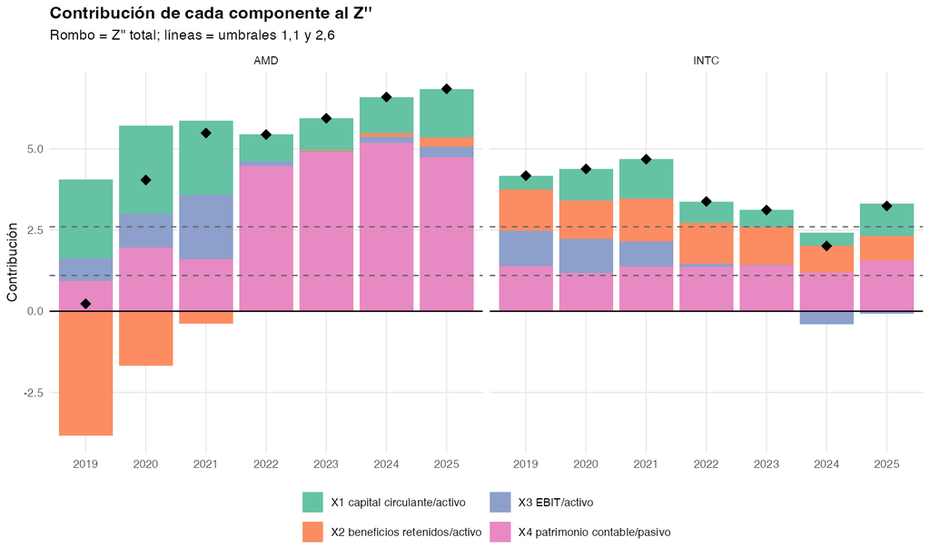

Figura 8: Contribuciones al Z’’ por componente.

```r
include_graphics("figures/fig07_altman_contribuciones.png")
```

- **AMD:** el **69 %** de su Z’’ viene de X4. Su patrimonio contable (63,0 B$) es 4,5 veces su pasivo, pero **41,8 B$ de ese patrimonio son fondo de comercio (25,1 B$) e intangibles (16,7 B$)** procedentes de Xilinx. X2 es casi cero porque AMD arrastraba **déficit acumulado** (-0,13 B$ en 2022): un artefacto histórico que la penaliza injustamente.
- **Intel:** su Z’’ se apoya en **stocks heredados** (beneficios retenidos de 49 B$ y patrimonio). **La rentabilidad actual (X3) resta.** Refleja más su historia que su capacidad presente de generar beneficio.

## 6.4 Qué explica el cambio de Intel en 2025

**Código**

```r
orig <- c(X1 = "Caja + inversiones suben con FCF negativo → **financiación**",
          X4 = "Patrimonio sube: más acciones y más minoritarios → **financiación**",
          X3 = "EBIT menos negativo; 2024 cargó reestructuración y deterioros que no se repiten",
          X2 = "Pérdida neta pequeña")
ac |> filter(modelo == "Z''", fiscal_year == 2025, ticker == "INTC", componente != "TOTAL") |>
  mutate(k = str_extract(componente, "^X\\d")) |> arrange(desc(cambio_vs_anio_anterior)) |>
  transmute(Componente = componente, `Δ 2024→2025` = paste0(ifelse(cambio_vs_anio_anterior > 0, "+", ""), fnum(cambio_vs_anio_anterior)),
            Origen = orig[k]) |>
  kbl(format = "html", escape = FALSE, align = "lrl") |>
  kable_styling(bootstrap_options = c("striped", "hover", "condensed"), full_width = FALSE)
fin_share <- (Cc("INTC",2025,"X1","cambio_vs_anio_anterior") + Cc("INTC",2025,"X4","cambio_vs_anio_anterior")) / Cc("INTC",2025,"TOTAL","cambio_vs_anio_anterior")
```

Tabla 11: Cambio del Z’’ de Intel entre 2024 y 2025 por componente.

| Componente | Δ 2024→2025 | Origen |
| --- | --- | --- |
| X1 capital circulante/activo | +0,61 | Caja + inversiones suben con FCF negativo → **financiación** |
| X4 patrimonio contable/pasivo | +0,35 | Patrimonio sube: más acciones y más minoritarios → **financiación** |
| X3 EBIT/activo | +0,33 | EBIT menos negativo; 2024 cargó reestructuración y deterioros que no se repiten |
| X2 beneficios retenidos/activo | -0,06 | Pérdida neta pequeña |

- **El 78 % de la mejora es de financiación.** Descontando cargos no recurrentes (escenario S1), el EBIT subyacente de Intel pasa de negativo en 2024 a ~0 en 2025: algo de mejora operativa por el recorte de costes, pero **solo lleva a Intel al punto de equilibrio**.
- **Ajuste por minoritarios (S4):** X4 incluye 12,1 B$ de minoritarios, derechos de socios sobre filiales concretas (fábricas), no del accionista de Intel. Sin ellos, el Z’’ de Intel 2025 baja a **3,09**. No cambia la zona.

## 6.5 Sensibilidad

**Código**

```r
as |> filter(fiscal_year %in% anios) |>
  mutate(cel = ifelse(is.na(z_pp), "n.d.", paste0(fnum(z_pp), " (", zona_z_pp, ")")), col = paste(ticker, fiscal_year)) |>
  select(escenario, col, cel) |>
  pivot_wider(names_from = col, values_from = cel) |>
  select(Escenario = escenario, all_of(paste("INTC", anios)), all_of(paste("AMD", anios))) |>
  kbl(format = "html", align = c("l", rep("r", 8)), col.names = c("Escenario", anios, anios)) |>
  kable_styling(bootstrap_options = c("striped", "hover", "condensed"), full_width = FALSE, font_size = 13) |>
  add_header_above(c(" " = 1, "Intel (INTC)" = 4, "AMD" = 4))
```

Tabla 12: Z’’ bajo distintos escenarios (zona entre paréntesis).

| Escenario | Intel (INTC) 2022 | Intel (INTC) 2023 | Intel (INTC) 2024 | Intel (INTC) 2025 | AMD 2022 | AMD 2023 | AMD 2024 | AMD 2025 |
| --- | --- | --- | --- | --- | --- | --- | --- | --- |
| Base: EBIT = OperatingIncomeLoss | 3,38 (segura) | 3,12 (segura) | 2,01 (gris) | 3,24 (segura) | 5,44 (segura) | 5,94 (segura) | 6,60 (segura) | 6,85 (segura) |
| S1: EBIT + reestructuración y otros cargos | 3,38 (segura) | 3,11 (segura) | 2,25 (gris) | 3,31 (segura) | 5,44 (segura) | 5,94 (segura) | 6,61 (segura) | 6,85 (segura) |
| S2: S1 + amortización de intangibles | 3,45 (segura) | 3,18 (segura) | 2,30 (gris) | 3,34 (segura) | n.d. | 6,22 (segura) | 6,85 (segura) | 7,05 (segura) |
| S3: EBIT base, X4 con patrimonio tangible (− fondo de comercio − intangibles) | 2,93 (segura) | 2,70 (segura) | 1,68 (gris) | 2,91 (segura) | 1,49 (gris) | 1,95 (gris) | 2,65 (segura) | 3,69 (segura) |
| S4: EBIT base, X4 sin minoritarios (patrimonio atribuible a la dominante) | 3,36 (segura) | 3,06 (segura) | 1,94 (gris) | 3,09 (segura) | 5,44 (segura) | 5,94 (segura) | 6,60 (segura) | 6,85 (segura) |

- **S1/S2 (definición de EBIT):** mueven poco el Z’’. **Ninguna zona cambia**: el diagnóstico no depende de cómo se traten los cargos extraordinarios. S1 es conservador para Intel (no suma los deterioros imputados en coste de ventas en 2024). S2 de AMD 2022 no está disponible (amortización de intangibles ausente en el JSON para ese año).
- **S3 (patrimonio tangible), el escenario decisivo para AMD:** al comprar Xilinx pagando en acciones *(fuente externa — verificar)*, AMD registró fondo de comercio e intangibles y **su patrimonio subió en la misma cuantía** (de 7,5 B$ a 54,8 B$) sin generar caja ni reducir pasivo. En una liquidación, el fondo de comercio vale ~0. Con patrimonio tangible, **AMD 2022 cae a 1,49 (gris)** y 2023 a 1,95; entra en zona segura en 2024 (2,65) y en 2025 queda en 3,69.
- **Intel es menos sensible:** su Z’’ 2025 baja de 3,24 a 2,91, por encima de 2,6 pero **al borde**.
- **Conclusión:** con patrimonio tangible, AMD sigue siendo más sólida en 2024–2025, pero la distancia en 2025 se reduce de 3,6 a 0,8 puntos; en 2022–2023 era Intel la que tenía mejor Z’’ tangible. **«AMD es mucho más solvente» depende de aceptar el fondo de comercio como colchón.**

**Código**

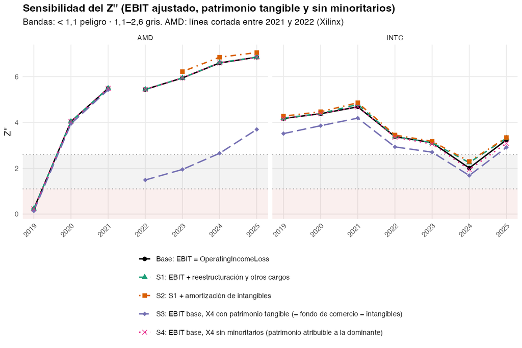

Figura 9: Sensibilidad del Z’’ por escenario.

```r
include_graphics("figures/fig08_altman_sensibilidad.png")
```

# 7 Z de mercado (original) no calculada y capitalizaciones de equilibrio

La Z original (1968) usa **capitalización bursátil / pasivo total** (término 0,6·X4ᵐ). El proyecto trabaja offline con datos del 10-K, sin precios de cotización, y **no se inventan precios**: la Z original queda como NA y se calcula la capitalización mínima para alcanzar cada umbral.

**Código**

```r
az |> filter(fiscal_year %in% 2024:2025) |>
  left_join(fi |> select(ticker, fiscal_year, shares_outstanding, stockholders_equity), by = c("ticker", "fiscal_year")) |>
  transmute(col = paste(ticker, fiscal_year),
            `Z sin término de mercado` = fnum(z_original_sin_termino_mercado),
            `Cap. para Z ≥ 1,81` = fb(`market_cap_necesaria_z_1.81`),
            `Cap. para Z ≥ 2,99` = fb(`market_cap_necesaria_z_2.99`),
            `Precio/acción equivalente (2,99)` = paste0(fnum(`market_cap_necesaria_z_2.99` / shares_outstanding, 1), " $"),
            `Precio / valor contable necesario (2,99)` = fx(`market_cap_necesaria_z_2.99` / stockholders_equity, 2)) |>
  pivot_longer(-col, names_to = "Concepto", values_to = "v") |>
  pivot_wider(names_from = col, values_from = v) |>
  select(Concepto, `INTC 2024`, `INTC 2025`, `AMD 2024`, `AMD 2025`) |>
  tabla(align = "lrrrr")
```

Tabla 13: Capitalización bursátil necesaria para Z ≥ 1,81 (salir de peligro) y Z ≥ 2,99 (zona segura). Precio/acción y múltiplo sobre valor contable derivados (capitalización / acciones; capitalización / patrimonio atribuible).

| Concepto | INTC 2024 | INTC 2025 | AMD 2024 | AMD 2025 |
| --- | --- | --- | --- | --- |
| Z sin término de mercado | 0,49 | 0,72 | 0,71 | 1,00 |
| Cap. para Z ≥ 1,81 | 200,5 B$ | 154,3 B$ | 21,3 B$ | 18,7 B$ |
| Cap. para Z ≥ 2,99 | 380,3 B$ | 321,6 B$ | 44,2 B$ | 46,1 B$ |
| Precio/acción equivalente (2,99) | 87,8 $ | 64,4 $ | 27,3 $ | 28,3 $ |
| Precio / valor contable necesario (2,99) | 3,83× | 2,81× | 0,77× | 0,73× |

- **AMD** alcanzaría la zona segura con una capitalización **inferior a su propio patrimonio contable**: cualquier valoración razonable para una empresa rentable la cumpliría.
- **Intel** necesitaría que el mercado la valorase a varias veces su valor contable. El umbral es exigente.
- **Siguiente paso:** introducir la capitalización a fecha de cierre de cada ejercicio (precio de cierre × acciones), **citando fuente y fecha**, en el parámetro `market_cap` de `altman_z.csv`.

# 8 Visión de analista de crédito

**¿Quién es más arriesgado? Intel, con claridad.**

Tabla 14: Comparativa de riesgo de crédito (2025)

| Factor | Intel | AMD |
| --- | --- | --- |
| Capacidad de servicio de la deuda | EBIT < intereses desde 2023; cobertura -2,0× | Cobertura 28×; caja neta |
| Generación de caja | FCF negativo 4 años (-44 B$ acumulados) | FCF positivo todos los años (+13,4 B$ acumulados) |
| Fuente de liquidez | Externa (acciones, socios, deuda) | Interna (operación) |
| Deuda | 46,6 B$ bruta; 9,2 B$ neta | 3,2 B$ bruta; caja neta 7,3 B$ |
| Tendencia de ingresos | -5,7 %/año | +13,6 %/año |
| Calidad del colchón de balance | Beneficios retenidos heredados; 12 B$ de minoritarios | Fondo de comercio + intangibles = 66 % del patrimonio |
| Principal riesgo | Ejecución del plan de fábricas y financiación continua | Inventario (142 días); deterioro del fondo de comercio |

- **Intel 2025 no es una recuperación, es una recapitalización.** La liquidez y el Z’’ mejoran porque entró capital; EBIT, FCF y cobertura siguen en negativo. **El punto clave de 2026+ es si el EBIT vuelve a cubrir intereses sin nuevas ampliaciones.** Además, la ampliación diluye al accionista existente y los minoritarios capturan parte de los flujos futuros de las fábricas.
- **AMD** no muestra tensiones de solvencia. Un analista de crédito vigilaría: (1) el inventario; (2) el riesgo de deterioro del fondo de comercio de 25 B$, que reduciría de golpe el patrimonio contable y el Z’’; (3) la concentración en un ciclo de producto.

# 9 Visión de negocio (salud financiera, no recomendación de inversión)

**AdvertenciaEsto no es asesoramiento de inversión**

Lo que sigue describe la salud financiera según los estados contables. No valora si las acciones están caras o baratas (no hay precios en el análisis) ni constituye una recomendación de compra o venta.

- **AMD: trayectoria de mejora en todos los frentes.** Crece, amplía márgenes, genera caja y apenas tiene deuda. Su rentabilidad contable (ROE 6,9 %) infravalora su rentabilidad económica por la amortización de Xilinx y un patrimonio inflado; el FCF (19 % de margen) da una imagen más fiel. Riesgos: inventario, valoración del fondo de comercio y ciclicidad del sector.
- **Intel: fase de transformación intensiva en capital y aún sin retorno.** Ingresos estancados y márgenes muy por debajo de su historia (margen operativo de 25 %–31 % en 2019–2021 frente a -4 % en 2025); activos que crecen sin ventas asociadas todavía; inversión financiada cada vez más con capital de terceros. **Los datos 2022–2025 no permiten evaluar si las fábricas en construcción generarán ingresos.**
- **Indicadores a seguir en los próximos 10-K:** Intel — EBIT/intereses > 1, FCF GAAP ≥ 0, rotación de activos, dilución y peso de los minoritarios. AMD — días de inventario, margen bruto, deterioros de fondo de comercio y Z’’ tangible.

# 10 Limitaciones

**Importante**

1. **n = 4 ejercicios × 2 empresas:** sin base para inferencia (ni p-valores, ni IC, ni tests de tendencia). Las tendencias se describen por dirección y monotonía; una partida extraordinaria puede dominar un año.
2. **Calibración antigua de Altman:** Z’’ (1995) y Z’ (1983) se calibraron con empresas de décadas pasadas; las zonas son **orientativas**, no probabilidades de quiebra. Z’’ y Z’ dan zonas distintas para Intel (segura frente a peligro): incertidumbre de modelo.
3. **Partidas no recurrentes:** Intel 2024 (reestructuración, deterioros y un probable cargo fiscal grande); AMD (2,3–2,8 B$/año de amortización de intangibles).
4. **Xilinx:** AMD 2019–2021 no es comparable con 2022–2025; el crecimiento de 2022 es inorgánico. Datos de la operación (fecha feb-2022, ~49 B$ en acciones, adquisición de Pensando) *(fuente externa — verificar)*.
5. **Ejercicio de 53 semanas en 2022** (ambas): ~+2 % en los flujos de ese año.
6. **Diferencias de definición entre empresas:** efectivo (Intel incluye restringido hasta 2023), inversiones a c/p (tags distintos) e intereses de Intel netos de capitalizados.
7. **FCF GAAP frente a ajustado:** el FCF de Intel aquí no descuenta las aportaciones de socios.
8. **Sin datos de mercado:** no hay Z original, ni ratios de valoración, ni *spreads* ni ratings.
9. **Hechos externos:** la identidad de los socios de capex de Intel (Brookfield/Apollo), los detalles de la operación Xilinx y el origen del aumento de acciones de Intel en 2025 no se derivan de EDGAR *(fuente externa — verificar)*.

## 11 Apéndice: metodología y reproducibilidad

- **Código:** `analysis/analysis.R` (R), ejecutado desde `/Users/binny/Desktop/current project` con `Rscript analysis/analysis.R`. Entrada: `data_raw/*_facts.json` (SEC EDGAR companyfacts, caché local). No se modifica ningún fichero del Día 1 (`day1_extract_clean.py`, `data_processed/`, `intc-amd-analysis.qmd`).
- **Salidas:** `analysis/results/*.csv`, `summary.json` (con el array `notes`) e índice `results/README.md`; figuras en `analysis/figures/`.
- **Método:** selección del ejercicio por fecha de cierre y duración; cadenas de tags alternativos documentadas en `extraccion_tags_usados.csv`; pasivo total derivado con control por suma de componentes; ratios de liquidez, solvencia, rentabilidad, eficiencia y caja; Altman Z’’ (primario) y Z’ (secundario) con contribuciones y cinco escenarios de sensibilidad (Base, S1–S4); capitalización de equilibrio para la Z original.
- **Este informe** (`informe.qmd`) no recalcula el análisis: lee los CSV y `summary.json` y reutiliza las figuras. Las únicas cifras derivadas aquí son sumas o cocientes directos de columnas (p. ej. FCF acumulado, precio/acción equivalente). La interpretación procede de `analysis/interpretation.md`.